# HW 6

Olga Lyashevskaya, George Moroz, Alla Tambovtseva and Ilya Schurov

There are several tasks on

- data manipulation with `dplyr` (if you have any problems see [this](https://www.datacamp.com/courses/dplyr-data-manipulation-r-tutorial) and [this](https://www.datacamp.com/courses/joining-data-in-r-with-dplyr) courses)
- data visualisation with `ggplot2` (if you have any problems see [this course](https://www.datacamp.com/courses/data-visualization-with-ggplot2-1))

.Rmd template for this homework is [here](https://raw.githubusercontent.com/LingData2019/LingData/master/hw/rmd-templates/HW6-template.Rmd).

### 1.

These datasets contain the results of the experiment that evaluates the inter speaker variation in noun class assignment among speakers of the Zilo dialect of Andi (a Nakh-Daghestanian language). In Zilo there are two classes for inanimate objects with no obvious semantic distinction between them.

There are two datasets:

- zilo_class_experiment_data.csv
- w_id — word id
- stimulus — stimuli word in Zilo
- translation_en — translation to English
- stimulus_source — the source of the stimulus: native or loan
- 1 … 16 — columns that contain answers of 16 speakers of Zilo: `b` or `r` (class markers)
- zilo_class_experiment_informants.csv
- s_id — speaker id (corresponds to numbers in the previous dataset)
- sex — sex of the speaker
- age_2017 — age of the speaker on the moment of the interview

### 1.1

Calculate the ratio of b-words ($\frac{b\text{-words}}{b\text{-words}+r\text{-words}}$) for each sex and stimulus source and visualise it with the following graph (it is possible to do within one pipe).

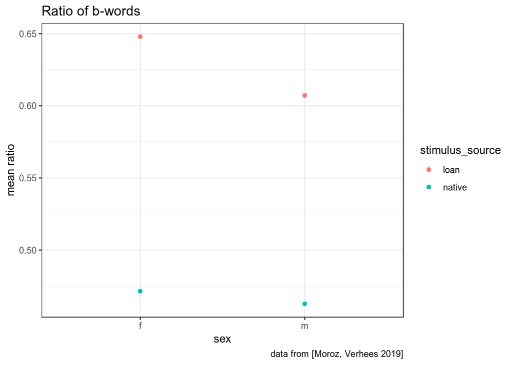

### 1.2

Calculate the ratio of b-words ($\frac{b\text{-words}}{b\text{-words}+r\text{-words}}$) for each stimulus and visualise ratio distribution using `geom_histogram`:

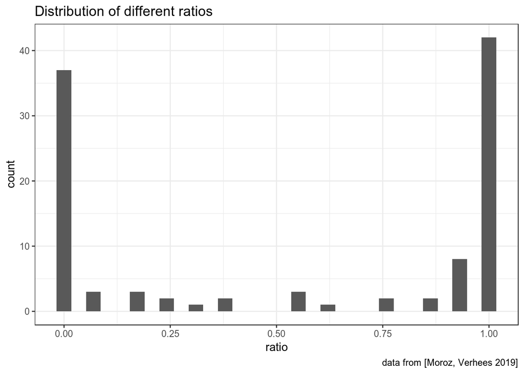

### 1.3

Calculate the ratio of b-words ($\frac{b\text{-words}}{b\text{-words}+r\text{-words}}$) for each stimulus. Which stimulae have value between 0.5 and 0.6?

### 2.

This dataset is based on (Coretta 2017, https://goo.gl/NrfgJm). This dissertation dealt with the relation between vowel duration and aspiration in consonants. Author carried out a data collection with 5 natives speakers of Icelandic. Then he extracted the duration of vowels followed by aspirated versus non-aspirated consonants. Check out whether vowels before aspirated consonants (like in Icelandic takka ‘key’ [tʰaʰka]) are signiﬁcantly shorter than vowels followed by non-aspirated consonants (like in kagga ‘barrel’ [kʰakka]).

Data are [here](http://math-info.hse.ru/f/2018-19/ling-data/icelandic.csv).

### 2.1

Calculate a 95% confidence interval and a mean vowel duration (variable `vowel.dur`) for different contexts (variable `aspiration`) for all speakers (variable `speaker`) and visualise them using `geom_pointrange`.

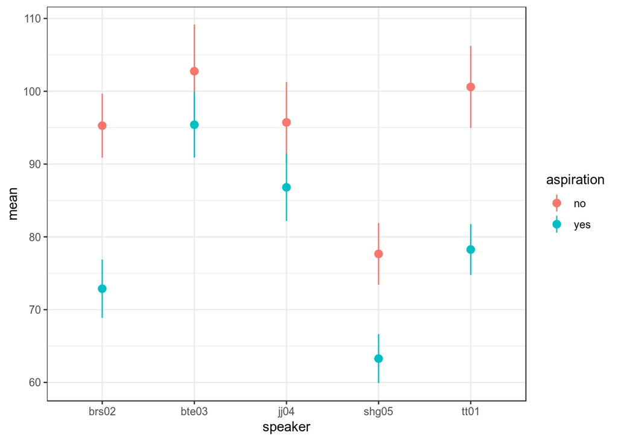